# Research Assessment Exercise

`Janhavi Namjoshi, janhavin@umd.edu`

# Analysis of Broadband Deployment and Internet Speeds in New York State using FCC Data - 2019

This Jupyter notebook presents an analysis of broadband availability in New York State using data from the Federal Communications Commission (FCC).

#### The study addresses the following questions:

1. What are the mean and median number of broadband providers per Census block? How many Census blocks have exactly the mean and median number of providers?
2. Is the number of broadband providers related to how fast the available internet is?
3. Is there variation in available internet speed by geography? Which areas or types of places have the fastest internet?

#### Key assumptions in the study:

1. All analysis is based on assumption that the advertised broadband speed is offered. Real speed may differ from the advertised speed.
2. Due to lack of availability of more recent shapefile, the map shape has been plotted from 2010 census block data. This assumption may introduce few errors in the analysis. It is based on assumptions that the 2019 data for broadband speed follows same block division as 2010 census block data. Data obtained from the United States Census Bureau.

### Data Exploration and Preprocessing

```python
# import necessary libraries
import pandas as pd
import numpy as np
import geopandas as gpd
import matplotlib.pyplot as plt
```

```python
# Load necessary datasets
# via https://opendata.fcc.gov/Wireline/Fixed-Broadband-Deployment-Data-December-2019/whue-6pnt
ny_data = pd.read_csv('Fixed_Broadband_Deployment_Data__December_2019.csv')

# shape file for Q3
# via https://www.census.gov/cgi-bin/geo/shapefiles/
block_level_shapefile = gpd.read_file("tl_2019_36_tabblock10.shp")


# import county name data for Q3
# via https://assets.pewresearch.org/wp-content/uploads/sites/7/2011/04/Census-2010-New-York-County-Database.xls
ny_county_name = pd.read_excel("Census-2010-New-York-County-Database.xls")
```

```python
# view datasets
ny_data.head()
```

|  | Logical Record Number | Provider ID | FRN | Provider Name | DBA Name | Holding Company Name | Holding Company Number | Holding Company Final | State | Census Block FIPS Code | Technology Code | Consumer | Max Advertised Downstream Speed (mbps) | Max Advertised Upstream Speed (mbps) | Business |
| --- | --- | --- | --- | --- | --- | --- | --- | --- | --- | --- | --- | --- | --- | --- | --- |
| 0 | 21413585 | 56800 | 14734107 | nysys wireless llc | NYSYS Wireless | Nysys Wireless LLC | 240074 | Nysys Wireless LLC | NY | 360999501001059 | 70 | 1 | 25.0 | 3.0 | 1 |
| 1 | 21703541 | 56843 | 3469442 | Verizon New York Inc. | Verizon New York Inc. | Verizon Communications Inc. | 131425 | Verizon Communications Inc. | NY | 360811483004015 | 50 | 1 | 940.0 | 880.0 | 1 |
| 2 | 28840093 | 58678 | 27756949 | Hudson Valley Wireless | Hudson Valley Wireless | Hudson Valley Wireless | 190188 | Hudson Valley Wireless | NY | 361150940001016 | 70 | 1 | 100.0 | 10.0 | 1 |
| 3 | 1204691 | 54458 | 4967055 | Windstream New York, Inc. | Windstream New York Inc. | Windstream Holdings, Inc. | 131413 | Windstream Holdings, Inc. | NY | 360130305003021 | 12 | 1 | 50.0 | 25.0 | 1 |
| 4 | 36174355 | 66677 | 27144112 | New Visions Communications Inc | New Visions Communications | New Visions Communications | 410187 | New Visions Communications Inc. | NY | 360670128003073 | 50 | 1 | 1000.0 | 1000.0 | 1 |

```python
block_level_shapefile.head()
```

|  | STATEFP10 | COUNTYFP10 | TRACTCE10 | BLOCKCE10 | GEOID10 | NAME10 | MTFCC10 | UR10 | UACE10 | UATYPE | FUNCSTAT10 | ALAND10 | AWATER10 | INTPTLAT10 | INTPTLON10 | geometry |
| --- | --- | --- | --- | --- | --- | --- | --- | --- | --- | --- | --- | --- | --- | --- | --- | --- |
| 0 | 36 | 003 | 950100 | 2010 | 360039501002010 | Block 2010 | G5040 | R | None | None | S | 7679 | 0 | +42.5081710 | -077.8840025 | POLYGON ((-77.88627 42.51209, -77.88604 42.511... |
| 1 | 36 | 099 | 950400 | 2008 | 360999504002008 | Block 2008 | G5040 | U | 32842 | C | S | 13532 | 0 | +42.9070061 | -076.8020465 | POLYGON ((-76.80342 42.90717, -76.80119 42.907... |
| 2 | 36 | 027 | 160005 | 1011 | 360271600051011 | Block 1011 | G5040 | U | 74314 | C | S | 44283 | 0 | +41.9238824 | -073.9067631 | POLYGON ((-73.90775 41.92209, -73.90760 41.922... |
| 3 | 36 | 093 | 032404 | 2023 | 360930324042023 | Block 2023 | G5040 | U | 00970 | U | S | 43121 | 0 | +42.8422037 | -073.9731978 | POLYGON ((-73.97489 42.84127, -73.97236 42.843... |
| 4 | 36 | 027 | 190301 | 1007 | 360271903011007 | Block 1007 | G5040 | U | 71803 | U | S | 0 | 9981 | +41.5903345 | -073.9317293 | POLYGON ((-73.93358 41.59004, -73.92967 41.590... |

```python
ny_county_name.head()
```

|  | County Name | COUNTY FIPS CODE | Total Population |
| --- | --- | --- | --- |
| 0 | Albany County | 36001 | 304204 |
| 1 | Allegany County | 36003 | 48946 |
| 2 | Bronx County | 36005 | 1385108 |
| 3 | Broome County | 36007 | 200600 |
| 4 | Cattaraugus County | 36009 | 80317 |

```python
# format County Name by removing ' County' from each entry to only keep name
ny_county_name['County Name'] = ny_county_name['County Name'].str.replace(' County', '')
```

```python
#convert required columns to required dtype
block_level_shapefile[['COUNTYFP10', 'GEOID10']] = block_level_shapefile[['COUNTYFP10', 'GEOID10']].astype(int)
ny_data['Census Block FIPS Code'] = ny_data['Census Block FIPS Code'].astype(int)
```

```python
#drop columns not required from shapefile
block_level_shapefile = block_level_shapefile.drop(block_level_shapefile.columns[5:13], axis=1)
block_level_shapefile.head()
```

|  | STATEFP10 | COUNTYFP10 | TRACTCE10 | BLOCKCE10 | GEOID10 | INTPTLAT10 | INTPTLON10 | geometry |
| --- | --- | --- | --- | --- | --- | --- | --- | --- |
| 0 | 36 | 3 | 950100 | 2010 | 360039501002010 | +42.5081710 | -077.8840025 | POLYGON ((-77.88627 42.51209, -77.88604 42.511... |
| 1 | 36 | 99 | 950400 | 2008 | 360999504002008 | +42.9070061 | -076.8020465 | POLYGON ((-76.80342 42.90717, -76.80119 42.907... |
| 2 | 36 | 27 | 160005 | 1011 | 360271600051011 | +41.9238824 | -073.9067631 | POLYGON ((-73.90775 41.92209, -73.90760 41.922... |
| 3 | 36 | 93 | 032404 | 2023 | 360930324042023 | +42.8422037 | -073.9731978 | POLYGON ((-73.97489 42.84127, -73.97236 42.843... |
| 4 | 36 | 27 | 190301 | 1007 | 360271903011007 | +41.5903345 | -073.9317293 | POLYGON ((-73.93358 41.59004, -73.92967 41.590... |

```python
block_level_shapefile['County FIPS'] = (block_level_shapefile['STATEFP10'].astype(str) + block_level_shapefile['COUNTYFP10'].astype(str).str.zfill(3)).astype(int)
block_level_shapefile.head()
```

|  | STATEFP10 | COUNTYFP10 | TRACTCE10 | BLOCKCE10 | GEOID10 | INTPTLAT10 | INTPTLON10 | geometry | County FIPS |
| --- | --- | --- | --- | --- | --- | --- | --- | --- | --- |
| 0 | 36 | 3 | 950100 | 2010 | 360039501002010 | +42.5081710 | -077.8840025 | POLYGON ((-77.88627 42.51209, -77.88604 42.511... | 36003 |
| 1 | 36 | 99 | 950400 | 2008 | 360999504002008 | +42.9070061 | -076.8020465 | POLYGON ((-76.80342 42.90717, -76.80119 42.907... | 36099 |
| 2 | 36 | 27 | 160005 | 1011 | 360271600051011 | +41.9238824 | -073.9067631 | POLYGON ((-73.90775 41.92209, -73.90760 41.922... | 36027 |
| 3 | 36 | 93 | 032404 | 2023 | 360930324042023 | +42.8422037 | -073.9731978 | POLYGON ((-73.97489 42.84127, -73.97236 42.843... | 36093 |
| 4 | 36 | 27 | 190301 | 1007 | 360271903011007 | +41.5903345 | -073.9317293 | POLYGON ((-73.93358 41.59004, -73.92967 41.590... | 36027 |

```python
#merge county names, population from ny_county_name to block_level_shapefile

# Perform the merge
block_level_shapefile = block_level_shapefile.merge(ny_county_name[['County Name', 'COUNTY FIPS CODE', 'Total Population']], left_on='County FIPS', right_on='COUNTY FIPS CODE', how='left')

# Drop the unnecessary columns
block_level_shapefile = block_level_shapefile.drop(columns=['COUNTY FIPS CODE'])

# Assign the 'COUNTY NAME' column to 'COUNTYNAME' in block_level_shapefile
block_level_shapefile.head()
```

|  | STATEFP10 | COUNTYFP10 | TRACTCE10 | BLOCKCE10 | GEOID10 | INTPTLAT10 | INTPTLON10 | geometry | County FIPS | County Name | Total Population |
| --- | --- | --- | --- | --- | --- | --- | --- | --- | --- | --- | --- |
| 0 | 36 | 3 | 950100 | 2010 | 360039501002010 | +42.5081710 | -077.8840025 | POLYGON ((-77.88627 42.51209, -77.88604 42.511... | 36003 | Allegany | 48946 |
| 1 | 36 | 99 | 950400 | 2008 | 360999504002008 | +42.9070061 | -076.8020465 | POLYGON ((-76.80342 42.90717, -76.80119 42.907... | 36099 | Seneca | 35251 |
| 2 | 36 | 27 | 160005 | 1011 | 360271600051011 | +41.9238824 | -073.9067631 | POLYGON ((-73.90775 41.92209, -73.90760 41.922... | 36027 | Dutchess | 297488 |
| 3 | 36 | 93 | 032404 | 2023 | 360930324042023 | +42.8422037 | -073.9731978 | POLYGON ((-73.97489 42.84127, -73.97236 42.843... | 36093 | Schenectady | 154727 |
| 4 | 36 | 27 | 190301 | 1007 | 360271903011007 | +41.5903345 | -073.9317293 | POLYGON ((-73.93358 41.59004, -73.92967 41.590... | 36027 | Dutchess | 297488 |

### Q1. What are the mean and median number of broadband providers per Census block? How many Census blocks have exactly the mean and median number of providers?

#### Additional question specific data wrangling

```python
# Count unique 'Provider Name' grouped by 'Census Block FIPS Code'
broadband_providers_per_census_block = ny_data.groupby(['Census Block FIPS Code'])['Provider Name'].count()
```

```python
# Calculate mean and rounded mean
mean_providers = broadband_providers_per_census_block.mean()
mean_providers_rounded = mean_providers.round(0)

# Calculate median
median_providers = broadband_providers_per_census_block.median()

# Count Census blocks with exactly the mean number of providers
mean_providers_count = (broadband_providers_per_census_block == mean_providers_rounded).sum()

# Count Census blocks with exactly the median number of providers
median_providers_count = broadband_providers_per_census_block[broadband_providers_per_census_block == median_providers].count()
```

```python
# Define function for histogram to visualize broadband providers per block

def histogram_providers(broadband_providers_per_census_block):
    # Set up the figure
    plt.figure(figsize=(12, 6))

    # Plot the histogram
    n, bins, _ = plt.hist(broadband_providers_per_census_block, bins=20, color='skyblue', edgecolor='black')

    # Add labels and title
    plt.xlabel('Number of Broadband Providers')
    plt.ylabel('Frequency')
    plt.title('Distribution of Broadband Providers per Census Block')

    # Add labels on top of each bar
    for i in range(len(n)):
        plt.text(bins[i]+(bins[i+1]-bins[i])/2, n[i], str(int(n[i])), ha='center', va='bottom' ,rotation=0)

    # Add a vertical line at a specific x-coordinate
    plt.axvline(x=median_providers, color='black', linestyle='--', label='Median')

    # Add a vertical line for the mean
    plt.axvline(x=mean_providers, color='orange', linestyle='--', label='Mean')

    # Set x-axis ticks
    plt.xticks(rotation=45)  # Rotate x-axis labels by 45 degrees
    plt.xticks(range(0, 38, 2))  # Set ticks for even numbers from 0 to 36

    # Show the plot
    plt.legend()  # Display the legend for the vertical line
    plt.show()
```

#### Analysis of mean and median broadband providers per Census block

```python
# Get summary statistics-
broadband_providers_per_census_block.describe()
```

```
count    350169.000000
mean          6.356117
std           1.963322
min           1.000000
25%           5.000000
50%           6.000000
75%           7.000000
max          36.000000
Name: Provider Name, dtype: float64
```

```python
# Print mean and rounded mean
print(f"Mean number of broadband providers per Census block: {mean_providers:.2f}")
print(f"Rounded mean number of broadband providers per Census block: {mean_providers_rounded}")

# Print median
print(f"Median number of broadband providers per Census block: {median_providers}")
print(f"The number of Census blocks with exactly the mean number of providers is: {mean_providers_count}")
print(f"The number of Census blocks with exactly the median number of providers is: {median_providers_count}")
```

```
Mean number of broadband providers per Census block: 6.36
Rounded mean number of broadband providers per Census block: 6.0
Median number of broadband providers per Census block: 6.0
The number of Census blocks with exactly the mean number of providers is: 83422
The number of Census blocks with exactly the median number of providers is: 83422
```

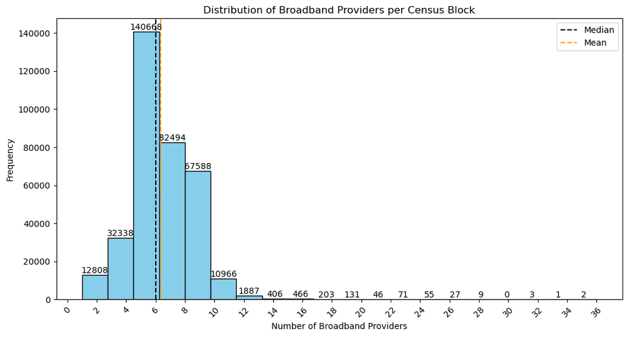

```python
histogram_providers(broadband_providers_per_census_block)
```

#### Mean and median providers:

- The mean number of broadband providers per Census block is approximately 6.36.
- The rounded mean number of providers is 6.0.
- The median number of providers per Census block is 6.0.

On average, each Census block in New York has around 6 broadband providers. The median value 6 shows that half of the census blocks in New York state have 6 or fewer broadband providers, and the other half have 6 or more.

#### Distribution of providers:

There are 83,422 Census blocks with exactly the rounded mean number of providers (6). There are also 83,422 Census blocks with exactly the median number of providers (6).

#### Categorization of blocks:

This distribution of providers across Census blocks indicates majority of blocks fall have 4-7 providers. This suggests a relatively competitive environment for broadband providers in these areas. However, there are significant numbers of blocks with fewer providers. This may indicate to a potential gap in broadband access.

#### Additional analysis from summary statistics:

The minimum value 1 indicates there are areas with limited broadband provider options. There are also Census blocks with 36 broadband providers.

### Q2. Is the number of broadband providers related to how fast the available internet is?

#### Additional question specific data wrangling

```python
# Calculate number of providers per block and mean downstream speed
block_speed_df = (ny_data.groupby('Census Block FIPS Code')
            .agg(Number_of_Providers=('Provider Name', 'nunique'),
                 Average_Downstream_Speed=('Max Advertised Downstream Speed (mbps)', 'mean'),
                Average_Upstream_Speed= ('Max Advertised Upstream Speed (mbps)', 'mean'))
            .reset_index())
```

```python
block_speed_df.head()
```

|  | Census Block FIPS Code | Number_of_Providers | Average_Downstream_Speed | Average_Upstream_Speed |
| --- | --- | --- | --- | --- |
| 0 | 360010001001000 | 2 | 30.000000 | 3.500000 |
| 1 | 360010001001001 | 5 | 17.400000 | 2.260000 |
| 2 | 360010001001002 | 5 | 17.400000 | 2.260000 |
| 3 | 360010001001003 | 5 | 17.400000 | 2.260000 |
| 4 | 360010001001004 | 9 | 117.666667 | 5.340889 |

```python
def correlation_plots(block_speed_df):
    fig, (ax1, ax2) = plt.subplots(1, 2, figsize=(12, 5))

    # Plot 1: Downstream Speed vs. Number of Providers
    x1 = block_speed_df['Number_of_Providers']
    y1 = block_speed_df['Average_Downstream_Speed']
    ax1.scatter(x1, y1)
    ax1.set_xlabel('Number of Providers')
    ax1.set_ylabel('Average Downstream Speed (mbps)')
    ax1.set_title('Downstream Speed vs. Number of Providers')

    # Plot 2: Upstream Speed vs. Number of Providers
    x2 = block_speed_df['Number_of_Providers']
    y2 = block_speed_df['Average_Upstream_Speed']
    ax2.scatter(x2, y2)
    ax2.set_xlabel('Number of Providers')
    ax2.set_ylabel('Average Upstream Speed (mbps)')
    ax2.set_title('Upstream Speed vs. Number of Providers')

    plt.tight_layout()  # Ensure proper spacing between subplots
    plt.show()
```

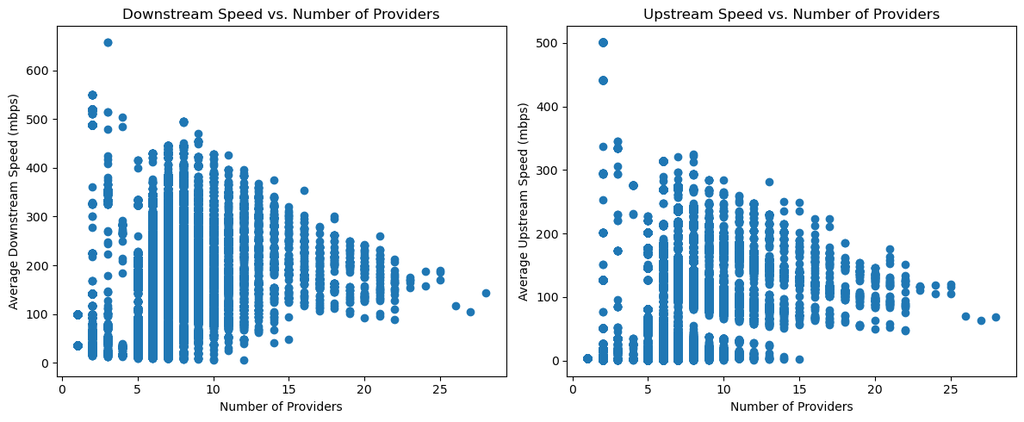

```python
correlation_plots(block_speed_df)
```

#### Overall trend

From the scatter plots, it can be observed that the average broadband speed (both Upstream and Downstream) decreases with the number of providers. However, this does not imply anything about the speed provided by individual providers.

#### Relationship between the number of broadband providers and broadband speed:

1. Places with less than 10 providers have the highest average broadband speeds, with highest 600+ Mbps downstream speed.
2. Even in blocks with fewer providers, many offer speeds of about 50 Mbps.
3. As number of providers go over 10, there is a significant drop in average speed offered in a Census Block. The maximum downstream speed goes from 400+ mbps to 300 Mbps with additional 5 providers in the block.
4. There is still a significant variation in broadband speeds within each category of the number of providers. For example, there are many providers allowing a speed of less than 50 Mbps even in areas with fewer providers.
5. There are also some providers in areas with more than 15 providers that offer speeds of more than 100 Mbps.

#### Potential explanations

1. Infrastructure investment: In areas with fewer providers, the existing providers may have invested more in infrastructure, leading to higher speeds. In contrast, areas with many providers may have a mix of older and newer infrastructure.
2. Oversubscription of networks: Most internet providers oversubscribe their connections. This implies that not every customer in an area will get the maximum speeds if they attempt to use their connection at the same time. This can lead to a substantial slowdown in speed in peak usage hours. Source: https://updater.com/guides/internet-speeds-advertised-vs-actual

Note: All analysis is based on assumption that the advertised broadband speed is offered. Real speed may differ from the advertised speed.

### Q3. Is there variation in available internet speed by geography? Which areas or types of places have the fastest internet?

#### Additional question specific data wrangling

```python
block_speed_df
```

|  | Census Block FIPS Code | Number_of_Providers | Average_Downstream_Speed | Average_Upstream_Speed |
| --- | --- | --- | --- | --- |
| 0 | 360010001001000 | 2 | 30.000000 | 3.500000 |
| 1 | 360010001001001 | 5 | 17.400000 | 2.260000 |
| 2 | 360010001001002 | 5 | 17.400000 | 2.260000 |
| 3 | 360010001001003 | 5 | 17.400000 | 2.260000 |
| 4 | 360010001001004 | 9 | 117.666667 | 5.340889 |
| ... | ... | ... | ... | ... |
| 350164 | 361231505004022 | 7 | 251.500000 | 11.662500 |
| 350165 | 361231505004023 | 6 | 333.666667 | 15.383333 |
| 350166 | 361231505004024 | 2 | 517.500000 | 26.500000 |
| 350167 | 361231505004025 | 2 | 517.500000 | 26.500000 |
| 350168 | 361231505004026 | 2 | 517.500000 | 26.500000 |

350169 rows × 4 columns

```python
# Convert FIPS code to string
block_speed_df['Census Block FIPS Code'] = block_speed_df['Census Block FIPS Code'].astype(str)

# Define a function to split FIPS code
def split_fips(fips_code):
    state = fips_code[:2]
    county = fips_code[2:5]
    tract = fips_code[5:11]
    block = fips_code[11:]
    return state, county, tract, block

# Apply the function to the column
block_speed_df[['State', 'County', 'Tract', 'Block']] = block_speed_df['Census Block FIPS Code'].apply(lambda x: pd.Series(split_fips(x)))
```

```python
# Display the updated DataFrame
block_speed_df.head()
```

|  | Census Block FIPS Code | Number_of_Providers | Average_Downstream_Speed | Average_Upstream_Speed | State | County | Tract | Block |
| --- | --- | --- | --- | --- | --- | --- | --- | --- |
| 0 | 360010001001000 | 2 | 30.000000 | 3.500000 | 36 | 001 | 000100 | 1000 |
| 1 | 360010001001001 | 5 | 17.400000 | 2.260000 | 36 | 001 | 000100 | 1001 |
| 2 | 360010001001002 | 5 | 17.400000 | 2.260000 | 36 | 001 | 000100 | 1002 |
| 3 | 360010001001003 | 5 | 17.400000 | 2.260000 | 36 | 001 | 000100 | 1003 |
| 4 | 360010001001004 | 9 | 117.666667 | 5.340889 | 36 | 001 | 000100 | 1004 |

```python
# Convert 'Census Block FIPS Code' and 'County' columns to int for proper merging
block_speed_df['Census Block FIPS Code'] = block_speed_df['Census Block FIPS Code'].astype(int)
block_speed_df['County'] = block_speed_df['County'].astype(int)

# Merge 'block_speed_df' with 'block_level_shapefile'
block_speed_df = block_speed_df.merge(block_level_shapefile, left_on='Census Block FIPS Code', right_on='GEOID10', how='inner')
```

```python
gdf = gpd.GeoDataFrame(block_speed_df, geometry=block_speed_df['geometry'])
```

```python
gdf.head()
```

|  | Census Block FIPS Code | Number_of_Providers | Average_Downstream_Speed | Average_Upstream_Speed | State | County | Tract | Block | STATEFP10 | COUNTYFP10 | TRACTCE10 | BLOCKCE10 | GEOID10 | INTPTLAT10 | INTPTLON10 | geometry | County FIPS | County Name | Total Population |
| --- | --- | --- | --- | --- | --- | --- | --- | --- | --- | --- | --- | --- | --- | --- | --- | --- | --- | --- | --- |
| 0 | 360010001001000 | 2 | 30.000000 | 3.500000 | 36 | 1 | 000100 | 1000 | 36 | 1 | 000100 | 1000 | 360010001001000 | +42.6692483 | -073.7265036 | POLYGON ((-73.73008 42.66567, -73.72949 42.666... | 36001 | Albany | 304204 |
| 1 | 360010001001001 | 5 | 17.400000 | 2.260000 | 36 | 1 | 000100 | 1001 | 36 | 1 | 000100 | 1001 | 360010001001001 | +42.6698972 | -073.7281491 | POLYGON ((-73.73137 42.66761, -73.73136 42.667... | 36001 | Albany | 304204 |
| 2 | 360010001001002 | 5 | 17.400000 | 2.260000 | 36 | 1 | 000100 | 1002 | 36 | 1 | 000100 | 1002 | 360010001001002 | +42.6707832 | -073.7295143 | POLYGON ((-73.73312 42.66743, -73.73305 42.667... | 36001 | Albany | 304204 |
| 3 | 360010001001003 | 5 | 17.400000 | 2.260000 | 36 | 1 | 000100 | 1003 | 36 | 1 | 000100 | 1003 | 360010001001003 | +42.6689368 | -073.7309916 | POLYGON ((-73.73262 42.66774, -73.73123 42.669... | 36001 | Albany | 304204 |
| 4 | 360010001001004 | 9 | 117.666667 | 5.340889 | 36 | 1 | 000100 | 1004 | 36 | 1 | 000100 | 1004 | 360010001001004 | +42.6723258 | -073.7314217 | POLYGON ((-73.73588 42.66987, -73.73571 42.670... | 36001 | Albany | 304204 |

```python
# aggregate over county level to use county borders for map
county_shapes = gdf.dissolve(by='County FIPS', aggfunc='first')
```

#### Map functions for:

1. Population across New York State counties
2. Average broadband downstream speed across census blocks
3. Average broadband upstream speed across census blocks

```python
def population_across_ny(gdf):

    # Set up the figure and axis
    fig, ax = plt.subplots(1, 1, figsize=(10, 10))

    # Define the colormap and color range
    cmap = 'Blues'
    vmin = gdf['Total Population'].min()
    vmax = gdf['Total Population'].max()

    # Plot the GeoDataFrame with the total population for coloring
    plot = gdf.plot(column='Total Population', ax=ax, legend=True, cmap='YlGnBu', vmin=vmin, vmax=vmax, legend_kwds={'label': "Total Population"})

    # Get the colorbar object
    cbar = plot.get_figure().get_axes()[1]

    # Set the title for the colorbar
    cbar.set_title('Total Population')

    # Plot the grouped county shapes with borders
    county_shapes.boundary.plot(ax=ax, color=None, edgecolor='black', linewidth=0.5)

    # Add county names as text annotations
    for idx, row in county_shapes.iterrows():
        ax.annotate(row['County Name'], (row['geometry'].centroid.x, row['geometry'].centroid.y), color='black', fontsize=7, ha='center')

    plt.title("Total Population across the state of New York")

    # Show the map
    plt.show()
```

```python
def plot_downstream_speed_labeled(gdf):

    # Set up the figure and axis
    fig, ax = plt.subplots(1, 1, figsize=(10, 10))

    # Define the number of bins and the bin edges
    num_bins = 6
    bin_edges = [1, 10, 50, 100, 200, 400, float('inf')]

    # Cut the data into bins
    gdf['Average_Downstream_Speed_bins'] = pd.cut(gdf['Average_Downstream_Speed'], bins=bin_edges, labels=False)

    # Plot the GeoDataFrame with the downstream speed category for coloring
    plot = gdf.plot(column='Average_Downstream_Speed', ax=ax, legend=True, cmap='YlGnBu', legend_kwds={'label': "Downstream Speed in Mbps"})

    # Get the colorbar object
    cbar = plot.get_figure().get_axes()[1]

    # Set the title for the colorbar
    cbar.set_title('Average Downstream Speed in Mbps')

    # Plot the grouped county shapes with borders
    county_shapes.boundary.plot(ax=ax, color=None, edgecolor='black', linewidth=0.5)

    # Add county names as text annotations
    for idx, row in county_shapes.iterrows():
        ax.annotate(row['County Name'], (row['geometry'].centroid.x, row['geometry'].centroid.y), color='black', fontsize=7, ha='center')

    plt.title("Downstream Speed across the state of New York (labeled with counties)")

    # Show the map
    plt.show()
```

```python
def plot_upstream_speed_labeled(gdf):

    # Set up the figure and axis
    fig, ax = plt.subplots(1, 1, figsize=(10, 10))

    # Define the number of bins and the bin edges
    num_bins = 6
    bin_edges = [1,5, 10, 25, 50, 100, float('inf')]

    # Cut the data into bins
    gdf['Average_Upstream_Speed_bins'] = pd.cut(gdf['Average_Upstream_Speed'], bins=bin_edges, labels=False)

    # Plot the GeoDataFrame with the downstream speed category for coloring
    plot = gdf.plot(column='Average_Upstream_Speed', ax=ax, legend=True, cmap='YlGnBu', legend_kwds={'label': "Upstream Speed in Mbps"})

    # Get the colorbar object
    cbar = plot.get_figure().get_axes()[1]

    # Set the title for the colorbar
    cbar.set_title('Average Upstream Speed in Mbps')

    # Plot the grouped county shapes with borders
    county_shapes.boundary.plot(ax=ax, color=None, edgecolor='black', linewidth=0.5)

    # Add county names as text annotations
    for idx, row in county_shapes.iterrows():
        ax.annotate(row['County Name'], (row['geometry'].centroid.x, row['geometry'].centroid.y), color='black', fontsize=7, ha='center')

    plt.title("Upstream Speed across the state of New York (labeled with counties)")

    # Show the map
    plt.show()
```

##### Note:

Due to lack of availability of more recent shapefile, the map shape has been plotted from 2010 census block data. This assumption may introduce few errors in the analysis. It is based on assumptions that the 2019 data for broadband speed follows same block division as 2010 census block data. Data obtained from the United States Census Bureau.

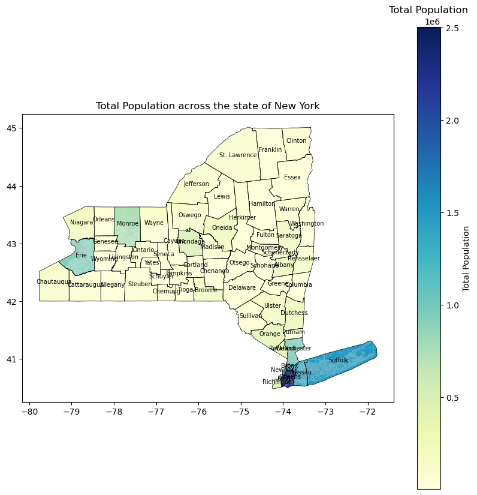

```python
population_across_ny(gdf)
```

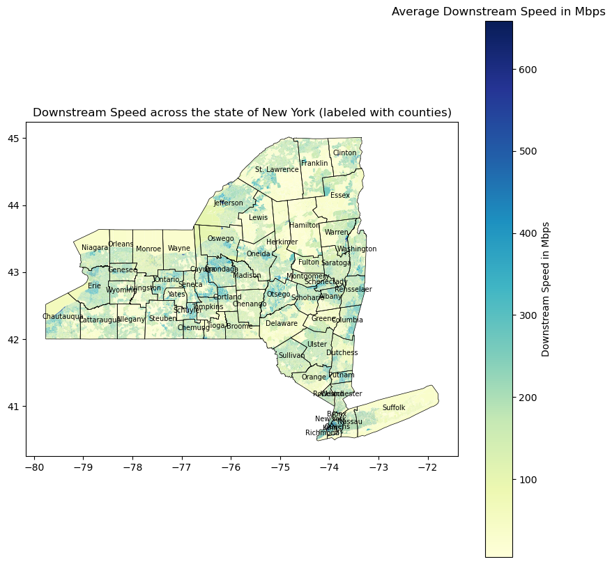

```python
plot_downstream_speed_labeled(gdf)
```

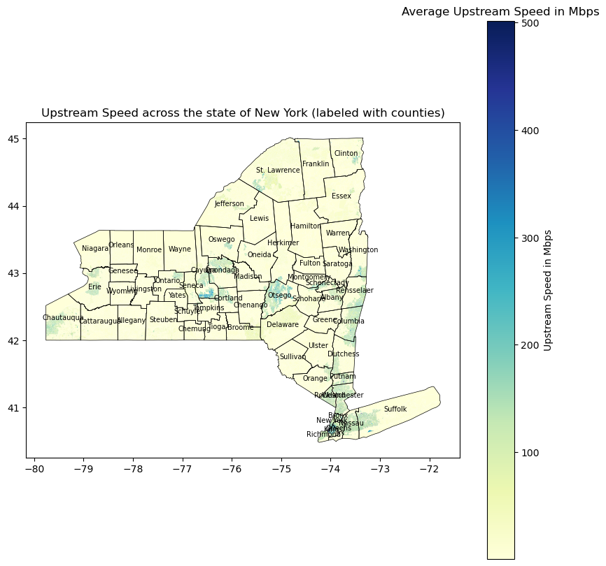

```python
plot_upstream_speed_labeled(gdf)
```

An “unserved” is defined as an area where the fastest available advertised internet download speed offered by a wireline-based provider is less than 25 Mbps. An “underserved” area is defined as an area where broadband service is only available from a wireline-based provider at advertised internet download speeds between 25 Mbps and 99 Mbps.

Source: https://broadband.ny.gov/new-ny-broadband-program

From the average downstream speed map, a large number of counties with <100 Mbps broadband speed on average are observed.

### Conclusions

There is a large discrepancy in broadband availability across New York State. It suggests there is an additional need for research to understand factors leading to this. Effective strategies need to be identified for improving broadband acess in rural and underserved areas while promoting a healthy competition between providers.

There is a possibility of impact of broadband speed having an impact on economic development, education and other social outcomes. Industry stakeholders and policy makers can study these discrepencies to develop effective policies and programs to improve broadband access to the state.